# Crowdsourced Cyclospora Watch

# Crowdsourced Cyclospora Watch

*Last updated: October 06, 2026 at 09:42 PM UTC*

# Feeling sick or have a confirmed case of cyclospora? [Submit your report here](https://forms.gle/QxB54kJSZV4cCFzQ6)

**167** responses collected so far. This is a self-reported, crowdsourced tracker built to try to spot patterns in the current multistate cyclospora outbreak — **not** an official CDC or state health department investigation. There is no control group, so results below are proportional reporting among people who got sick, not proof of cause. Treat this as “worth watching,” not “confirmed.”

## How certain is it that these are cyclospora cases?

The form asks everyone why they believe they have cyclospora. **27 of 167 responses (16.2%) are lab confirmed.** Another **124 (74.3%) are self-suspected** — people who have the symptoms and think they have it, without a test.

| Case definition | # responses | % of responses |
| --- | --- | --- |
| Lab confirmed | 27 | 16.2 |
| Treated by a clinician, not lab confirmed | 7 | 4.2 |
| Awaiting or inconclusive lab result | 7 | 4.2 |
| Self-suspected | 124 | 74.3 |
| Unclassified | 2 | 1.2 |

**Every number on this page is computed over all 167 responses, including the self-suspected ones.** That is deliberate. Excluding them would discard most of the data and bias what remains toward whoever was able to get a stool test — which is a function of healthcare access, not of what someone ate. But it does mean the leads below describe a mostly self-diagnosed population, and that is a real limit on how far any of them should be pushed.

*Free-text answers here are counted, never quoted — some mention unrelated medical conditions. “Unclassified” means an answer didn’t clearly fit any tier, not that it was discarded.*

# Charts

## Chart 1: Top Produce Leads by Signal Ratio

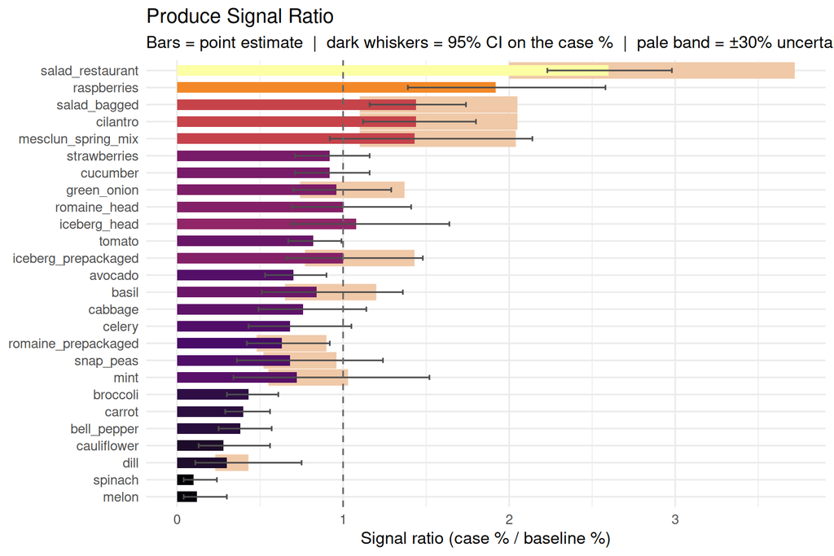

*See Table 1 below for the full data, including confidence intervals.*

## Chart 2: Cases by State

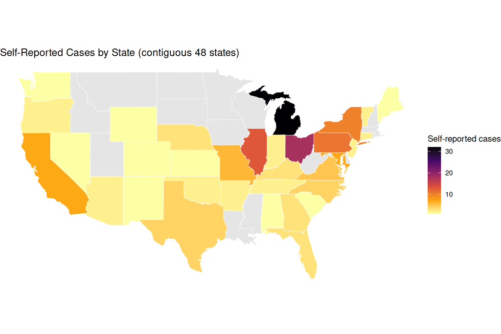

*This is a representation of the cases that have been self-reported in this survey. For the official case count, please refer to the CDC or your relevant state/local health department. See Table 2 below for the full state-by-state count.*

## Chart 3: Cases by Canadian Province

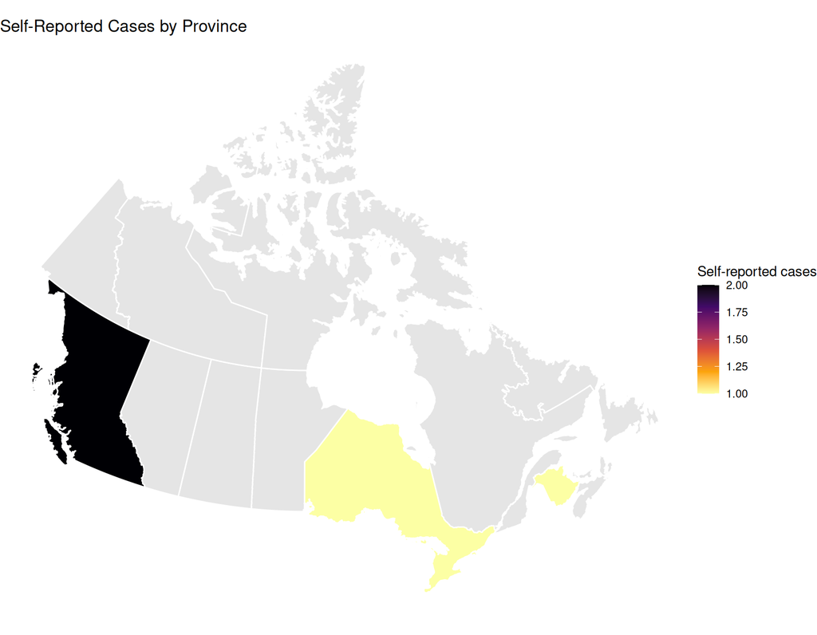

*See Table 3 below for the full province-by-province count.*

## Chart 4: Epi Curve

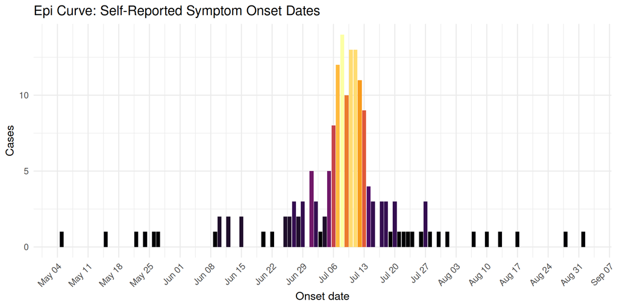

*See Table 4 below for the full date-by-date case counts.*

## Chart 5: Reddit Thread Parsed Sources

This is a hand-compiled tally of food/restaurant mentions from Reddit threads, kept separate from the statistical analysis above since it doesn’t have the per-person structure needed for the confidence intervals or signal ratios. Read as “what’s been mentioned together,” not as a statistical finding.

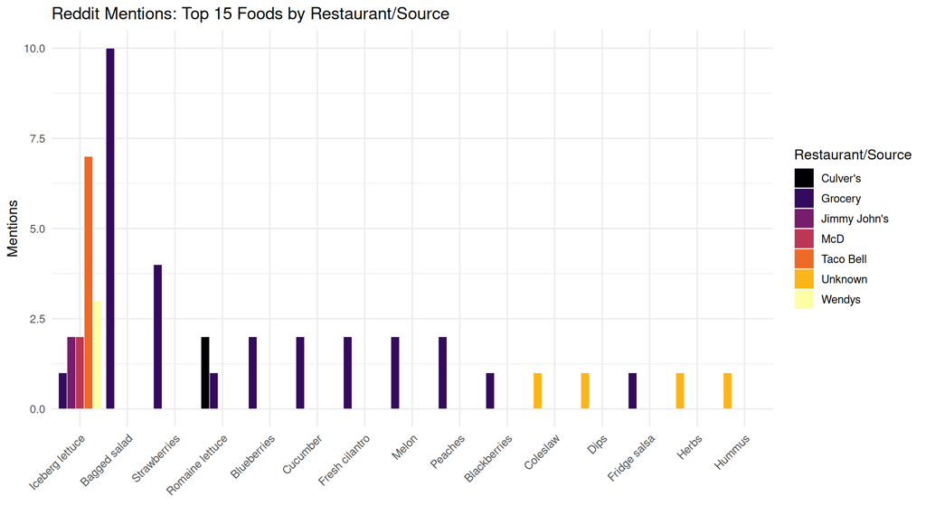

*See Table 5 below for the full mention tally (all restaurants/foods, not just the top 15 shown here).*

# Data Tables

## Table 1: Produce Signal Ratio (Full Data)

| Food | # cases | % of cases | CI low | CI high | via checklist | via free text | Baseline % (used in ratio) | Baseline source | ERS reference (not used in ratio) | Signal ratio | Ratio CI low | Ratio CI high |
| --- | --- | --- | --- | --- | --- | --- | --- | --- | --- | --- | --- | --- |
| salad_restaurant | 87 | 52.1 | 44.6 | 59.5 | 85 | 4 | 20 | author estimate | — | 2.6 | 2.23 | 2.98 |
| raspberries | 32 | 19.2 | 13.9 | 25.8 | 32 | 0 | 10 | USDA ERS | 0.9 lb/yr (2021) | 1.92 | 1.39 | 2.58 |
| salad_bagged | 60 | 35.9 | 29 | 43.4 | 56 | 7 | 25 | author estimate | — | 1.44 | 1.16 | 1.74 |
| cilantro | 48 | 28.7 | 22.4 | 36 | 48 | 0 | 20 | author estimate | — | 1.44 | 1.12 | 1.8 |
| mesclun_spring_mix | 19 | 11.4 | 7.4 | 17.1 | 19 | 0 | 8 | author estimate | — | 1.43 | 0.92 | 2.14 |
| cucumber | 46 | 27.5 | 21.3 | 34.8 | 46 | 0 | 30 | USDA ERS | 8.2 lb/yr (2022) | 0.92 | 0.71 | 1.16 |
| strawberries | 46 | 27.5 | 21.3 | 34.8 | 46 | 0 | 30 | USDA ERS | 7.3 lb/yr (2021) | 0.92 | 0.71 | 1.16 |
| green_onion | 32 | 19.2 | 13.9 | 25.8 | 32 | 0 | 20 | author estimate | — | 0.96 | 0.7 | 1.29 |
| iceberg_head | 18 | 10.8 | 6.9 | 16.4 | 18 | 0 | 10 | USDA ERS | 10.3 lb/yr (2022) | 1.08 | 0.69 | 1.64 |
| romaine_head | 25 | 15 | 10.4 | 21.2 | 25 | 0 | 15 | USDA ERS | 12.7 lb/yr (2022) | 1 | 0.69 | 1.41 |

[output cut: 17 more lines]

*CI columns are a 95% confidence interval — small sample sizes mean wide ranges. If the “Ratio CI low” column is still above 1, that’s a stronger lead than the point estimate alone.*

### Where these baselines come from

The signal ratio divides how often cases report a food by a **baseline** — how commonly people eat it normally. That denominator drives every number in this table, so it’s worth being explicit about where it comes from.

Of the 27 foods below, **15 have a baseline sourced from USDA ERS** and **12 rest on the author’s own estimate**. Both are labeled in the “Baseline source” column.

- **Author estimates** are exactly that — considered guesses, not measurements, and not derived from any survey. They carry a **pale ±30% band** on the chart above to show roughly how much the ratio would move if the guess were off by that much. The band is one flat width for every estimate; pretending to know which guesses are shakier than others would be false precision.
- **USDA ERS** values come from the [Food Availability (Per Capita) Data System](https://www.ers.usda.gov/data-products/food-availability-per-capita-data-system), refreshed monthly into `baselines-external.json`.

**The ERS column is shown but not yet used**, and the reason is a real limitation rather than an oversight. ERS publishes *pounds of food available per person per year*; the baseline this ratio needs is *the share of people who ate a food in a two-week window*. Those measure different things and cannot be converted into one another — 19 lb of tomatoes a year could be everyone eating a little or a few people eating a lot. Substituting one for the other would change every ratio on this page for no reason but a change of units. Reconciling them properly is open work; until then both numbers are shown side by side so the gap is visible rather than hidden.

### Reported, but not yet rankable

A signal ratio needs a denominator, so a food with no baseline can’t appear in the table above. That’s **34 of the 61 foods reported so far** — not a rounding error, and previously they simply vanished from the page with nothing said. They are listed here instead.

| Food | # cases | % of cases | via checklist | via free text |
| --- | --- | --- | --- | --- |
| lettuce_unspecified | 14 | 8.4 | 12 | 2 |
| tacos | 9 | 5.4 | 0 | 9 |
| no_specific_item | 8 | 4.8 | 0 | 8 |
| cherries | 5 | 3 | 0 | 5 |
| grapes | 5 | 3 | 0 | 5 |
| onions | 5 | 3 | 0 | 5 |
| lettuce_untyped | 4 | 2.4 | 0 | 4 |
| apples | 3 | 1.8 | 0 | 3 |
| bananas | 3 | 1.8 | 0 | 3 |
| blueberries | 3 | 1.8 | 0 | 3 |

[output cut: 24 more lines]

Two different reasons a food is on this list, and they need different fixes:

- **Ordinary produce with no baseline yet** — `lettuce_unspecified`, onions, grapes, cherries, apples and the like. These *could* be ranked; they just need a “how often does a normal person eat this” number added to `category_vocabulary.json`. Adding one moves the food straight into the table above. `lettuce_unspecified` is the largest by some way, and the most worth doing: it is lettuce whose **type** the checklist recorded but whose form it didn’t, so it is ordinary produce rather than an unrankable composite.
- **Foods no per-capita figure can describe** — dishes and composites like `tacos`, `sushi`, `beef_burger` or `veggie_tray`, and non-answers like `no_specific_item`. There is no meaningful “percent of people who ate a taco in a two-week window” to divide by, and inventing one would manufacture a ranking rather than measure it. These stay here permanently, which is the honest outcome, not a gap waiting to be filled.

`lettuce_untyped` is deliberately on this list too: it held the obsolete flat baseline of 55 while its siblings divide by 10–20, which published a signal ratio of 0.04 for what is otherwise a real lead. Removing the baseline was the fix.

## Table 2: Cases by State (Full Data)

| State | # cases |
| --- | --- |
| Michigan | 32 |
| Ohio | 18 |
| Illinois | 13 |
| Pennsylvania | 11 |
| New York | 10 |
| California | 7 |
| Maryland | 7 |
| Missouri | 6 |
| Virginia | 5 |
| North Carolina | 4 |

[output cut: 24 more lines]

## Table 3: Cases by Canadian Province (Full Data)

| Province | # cases |
| --- | --- |
| British Columbia | 2 |
| New Brunswick | 1 |
| Ontario | 1 |

## Table 4: Epi Curve Data (Full Data)

| Onset date | Cases |
| --- | --- |
| 2026-05-05 | 1 |
| 2026-05-15 | 1 |
| 2026-05-22 | 1 |
| 2026-05-24 | 1 |
| 2026-05-26 | 1 |
| 2026-05-27 | 1 |
| 2026-06-09 | 1 |
| 2026-06-10 | 2 |
| 2026-06-12 | 2 |
| 2026-06-15 | 2 |

[output cut: 41 more lines]

## Table 5: Reddit Mention Tally (Full Data)

| Restaurant/Source | Food | Mentions |
| --- | --- | --- |
| Grocery | Bagged salad | 10 |
| Taco Bell | Iceberg lettuce | 7 |
| Grocery | Strawberries | 4 |
| Wendys | Iceberg lettuce | 3 |
| Grocery | Fresh cilantro | 2 |
| Grocery | Blueberries | 2 |
| Grocery | Cucumber | 2 |
| Grocery | Peaches | 2 |
| Grocery | Melon | 2 |
| McD | Iceberg lettuce | 2 |

[output cut: 19 more lines]

## Table 6: All Produce Mentioned

Every food reported, whether or not it can be ranked. The last two columns show **how** each report arrived — a preset option someone ticked, or something they wrote in themselves.

| Food | # cases | % of cases | CI low | CI high | via checklist | via free text |
| --- | --- | --- | --- | --- | --- | --- |
| salad_restaurant | 87 | 52.1 | 44.6 | 59.5 | 85 | 4 |
| tomato | 62 | 37.1 | 30.2 | 44.7 | 61 | 2 |
| salad_bagged | 60 | 35.9 | 29 | 43.4 | 56 | 7 |
| cilantro | 48 | 28.7 | 22.4 | 36 | 48 | 0 |
| cucumber | 46 | 27.5 | 21.3 | 34.8 | 46 | 0 |
| strawberries | 46 | 27.5 | 21.3 | 34.8 | 46 | 0 |
| avocado | 41 | 24.6 | 18.6 | 31.6 | 41 | 0 |
| green_onion | 32 | 19.2 | 13.9 | 25.8 | 32 | 0 |
| raspberries | 32 | 19.2 | 13.9 | 25.8 | 32 | 0 |
| carrot | 27 | 16.2 | 11.4 | 22.5 | 27 | 0 |

[output cut: 51 more lines]

*A response can contribute to both columns — ticking “cilantro” on the checklist and also writing it in — so they can sum to more than the case count.*

## Table 7: Stores & Restaurants Mentioned

| Store/restaurant | # cases | % of cases | CI low | CI high |
| --- | --- | --- | --- | --- |
| taco_bell | 45 | 26.9 | 20.8 | 34.1 |
| walmart | 20 | 12 | 7.9 | 17.8 |
| kroger | 16 | 9.6 | 6 | 15 |
| meijer | 16 | 9.6 | 6 | 15 |
| aldi | 13 | 7.8 | 4.6 | 12.9 |
| costco | 11 | 6.6 | 3.7 | 11.4 |
| mcdonalds | 10 | 6 | 3.3 | 10.7 |
| trader_joes | 10 | 6 | 3.3 | 10.7 |
| chipotle | 9 | 5.4 | 2.9 | 9.9 |
| unspecified_restaurant | 9 | 5.4 | 2.9 | 9.9 |

[output cut: 118 more lines]

## Table 8: Reported Symptom Duration

Cyclospora illness tends to run longer than most foodborne bugs (often weeks, sometimes relapsing). Short-duration reports are more likely something else.

| Duration | # responses | % of responses |
| --- | --- | --- |
| Still sick | 119 | 71.3 |
| Between 1-3 weeks | 22 | 13.2 |
| Less than a week | 12 | 7.2 |
| 3+ weeks | 9 | 5.4 |
| Less than 48 hrs | 5 | 3 |

**How to read this page:** a high signal ratio means the food is reported by sick people more than you’d expect from normal eating habits — that’s a lead worth watching, not a verdict. Small numbers (a food only 2-3 people mentioned) are noisy and easy to over-read. If something looks concerning and consistent, the right next step is reporting it to your **local or state health department**, who can do formal case-control interviews and trace product lots — this page can’t do that part.

*Want to add your own report? [Fill out the form here](https://forms.gle/6zFfhiaGcw7xHDKa7).*

```
##   category names      194 ok
##   vocabulary integrity ok
```